# **Lab Assignment Seven: Sequential Network Architectures**

### **Analysis of Model Performance and Statistical Comparison**

In this lab, several deep learning models were evaluated for binary text classification using metrics such as precision, recall, and F1-score. The models included a baseline BiLSTM, an adjusted BiLSTM with increased units, a baseline Transformer with two attention layers, a Transformer with three layers, and a Transformer with two sequential attention layers. Each model incorporated **pre-trained GloVe embeddings**, providing semantic context to the input sequences, and underwent 5-fold stratified cross-validation to maintain a balanced class distribution across training and testing sets. This robust evaluation approach ensured consistent and reliable performance metrics. To determine the statistical significance of performance differences between models, paired t-tests were employed.

The BiLSTM models were first evaluated, with the baseline and adjusted configurations showing F1-scores that were close in value. The statistical comparison between the two resulted in a p-value of **0.0778**, indicating **no significant difference**. This suggests that increasing the LSTM units from 64 to 83 did not yield a substantial improvement, possibly because the baseline model was already capturing the relevant patterns in the dataset effectively with the help of the GloVe embeddings.

The Transformer models exhibited more variability. The comparison between the baseline two-layer Transformer and the three-layer Transformer yielded a p-value of **0.3972**, suggesting **no significant performance improvement** with the additional layer. This indicates that the two-layer architecture, supported by the semantic information from GloVe embeddings, was sufficient to model the data, and adding another layer increased the computational cost without significant performance gain.

### **Measures to Reduce Computational Cost**

Throughout the experiment, several measures were implemented to reduce computational cost and optimize training time without sacrificing model performance:

1. **Use of Pre-trained GloVe Embeddings:** The models incorporated pre-trained 50-dimensional GloVe embeddings. This approach leveraged semantic knowledge from a large corpus, enabling the models to converge faster and achieve better performance without requiring the embeddings to be trained from scratch.
2. **Truncated Input Sequences:** Instead of using the full length of text sequences, the input was truncated to 100 tokens. This reduced the dimensionality of input data and significantly lowered computational overhead, especially for Transformer models that scale quadratically with input length.
3. **Stratified K-Fold Cross-Validation with Fewer Splits:** The number of folds for cross-validation was set to 5 instead of a higher value like 10. This balanced the need for robust evaluation with reduced computational time.
4. **Early Stopping:** Early stopping was employed during model training to prevent unnecessary epochs once the validation loss stopped improving. This helped in reducing overfitting and saved significant time by terminating training early.
5. **Limited Epochs:** Each model was trained for a maximum of 5 epochs, which, combined with early stopping, ensured that models did not undergo prolonged training, reducing both training time and computational resources.
6. **Efficient Hyperparameter Choices:** The models were initially designed with moderate hyperparameters such as 64 units for the LSTM and 2-3 layers for the Transformer. More complex configurations were avoided to reduce the risk of excessive computational costs.
7. **Batch Size Optimization:** A batch size of 64 was chosen as it provided a balance between faster training (due to fewer gradient updates per epoch) and stable convergence. Smaller or larger batch sizes might have led to longer training times or unstable gradients.

### **Suggestions for Improvement**

Despite the efforts to optimize computational cost, several improvements could be explored in future experiments to achieve better performance:

1. **Hardware Optimization:** Utilizing GPUs or TPUs instead of CPUs could significantly reduce training time, especially for complex architectures like Transformers.
2. **Model Pruning and Quantization:** Applying techniques like model pruning, which removes unnecessary weights, or quantization, which reduces the precision of model parameters, can help reduce the model size and speed up inference without significant performance loss.
3. **Distributed Training:** Leveraging distributed training across multiple GPUs or nodes could reduce training time, especially for larger datasets or more complex models.
4. **Mixed Precision Training:** Using mixed precision (FP16) instead of full precision (FP32) during training can reduce memory usage and speed up computations, particularly for large models like Transformers.
5. **Hyperparameter Search Optimization:** Implementing automated hyperparameter optimization techniques such as random search or Bayesian optimization could help find more efficient configurations without manually experimenting with each parameter.
6. **Fine-tuning Pre-trained Models:** While GloVe embeddings were effective, future experiments could explore fine-tuning transformer-based pre-trained models like BERT or DistilBERT, which often require less data and time to converge compared to training deeper architectures from scratch.

By combining these strategies with the current methodology, future experiments could achieve better performance while maintaining or even reducing computational costs.

# **3. Exceptional Work**

### ConceptNet Numberbatch Embeddings

```python
# Conceptnet Embeddings
def load_conceptnet_embeddings(file_path):
    embeddings_index = {}
    with gzip.open(file_path, 'rt', encoding='utf-8') as f:  # 'rt' mode reads the file as text
        for line in f:
            values = line.split()
            word = values[0]
            coefs = np.asarray(values[1:], dtype='float32')
            embeddings_index[word] = coefs
    return embeddings_index

# Usage
embeddings_index = load_conceptnet_embeddings(
    r'C:\Users\Juan Dominguez\Downloads\numberbatch-en-19.08.txt.gz'
)
```

```python
# Checking Embeddings
print(f"Number of words loaded: {len(embeddings_index)}")
print("Sample embeddings:")
for word, vector in list(embeddings_index.items())[:5]:
    print(f"{word}: {vector[:5]}...")  # Print the first 5 values of each vector
```

```
Number of words loaded: 516783
Sample embeddings:
516782: [300.]...
##: [ 0.0295 -0.0405 -0.0341  0.0837 -0.0575]...
###: [ 0.0202 -0.0249 -0.0653  0.093  -0.0923]...
####: [ 0.0521 -0.0262 -0.0881  0.1085 -0.1168]...
#####: [ 0.0416  0.0061 -0.0388  0.0175 -0.0617]...
```

### GloVe Embeddings

```python
# Glove Embeddings
def load_glove_embeddings(file_path):
    embeddings_index = {}
    with open(file_path, 'r', encoding='utf-8') as f:
        for line in f:
            values = line.split()
            word = values[0]
            coefs = np.asarray(values[1:], dtype='float32')
            embeddings_index[word] = coefs
    return embeddings_index

# Usage
embeddings_index_glove = load_glove_embeddings(r'C:\Users\Juan Dominguez\Downloads\glove.6B\glove.6B.50d.txt')
```

```python
# Checking Embeddings
print(f"Number of words loaded: {len(embeddings_index_glove)}")
```

```
Number of words loaded: 400000
```

```python
# Checking Embeddings
for word, embedding in list(embeddings_index_glove.items())[:5]:
    print(f"{word}: {embedding[:5]}...")  # Prints the first 5 dimensions of each embedding
```

```
the: [ 0.418    0.24968 -0.41242  0.1217   0.34527]...
,: [ 0.013441  0.23682  -0.16899   0.40951   0.63812 ]...
.: [ 0.15164  0.30177 -0.16763  0.17684  0.31719]...
of: [ 0.70853  0.57088 -0.4716   0.18048  0.54449]...
to: [ 0.68047  -0.039263  0.30186  -0.17792   0.42962 ]...
```

```python
# Storing Conceptnet & Glove Embeddings
conceptnet_embeddings = load_conceptnet_embeddings(
    r'C:\Users\Juan Dominguez\Downloads\numberbatch-en-19.08.txt.gz'
)
glove_embeddings = load_glove_embeddings(
    r'C:\Users\Juan Dominguez\Downloads\glove.6B\glove.6B.50d.txt'
)
```

### Function to Build Embedding Matrix

```python
# Function to build embedding matrix
def build_embedding_matrix(embeddings_index, vocab, embedding_dim):
    embedding_matrix = np.zeros((len(vocab) + 1, embedding_dim))  # +1 for padding token
    for word_id, i in vocab.items():  # Iterates through vocabulary with indices
        vector = embeddings_index.get(str(word_id))  # Converts word_id to string if needed
        if vector is not None:
            embedding_matrix[i] = vector
    return embedding_matrix

# 'padded_text' is a list of tokenized sequences (list of integers)
if isinstance(df_preprocessed['padded_text'].iloc[0], np.ndarray):
    # Builds the vocabulary from the tokenized sequences (list of integers)
    vocab = {}
    index = 1  # Starting index for the vocabulary (1 for padding token)
    for sequence in df_preprocessed['padded_text']:
        for word_id in sequence:
            if word_id not in vocab:
                vocab[word_id] = index
                index += 1

    vocab_size = len(vocab) + 1  # +1 for padding token (index 0)
else:
    raise ValueError("'padded_text' must be a list of tokenized sequences.")

# Defines the embedding dimensions for GloVe and ConceptNet
embedding_dim_glove = 50
embedding_dim_conceptnet = 300  # ConceptNet typically uses 300 dimensions

# Creates the embedding matrices for GloVe and ConceptNet
glove_matrix = build_embedding_matrix(glove_embeddings, vocab, embedding_dim_glove)
conceptnet_matrix = build_embedding_matrix(conceptnet_embeddings, vocab, embedding_dim_conceptnet)

# Prints details for verification
print(f"Vocabulary size: {vocab_size}")
print(f"GloVe embedding matrix shape: {glove_matrix.shape}")
print(f"ConceptNet embedding matrix shape: {conceptnet_matrix.shape}")
```

```
Vocabulary size: 5000
GloVe embedding matrix shape: (5000, 50)
ConceptNet embedding matrix shape: (5000, 300)
```

```python
# Checking entries in vocab
print(f"First 10 entries in vocab: {list(vocab.items())[:10]}")
print(f"Shape of embedding matrix: {glove_matrix.shape}")  # Should match the embedding dimension and vocab size
```

```
First 10 entries in vocab: [(138, 1), (3133, 2), (1, 3), (1034, 4), (3111, 5), (3498, 6), (22, 7), (3322, 8), (11, 9), (45, 10)]
Shape of embedding matrix: (5000, 50)
```

### Bilstm With Embeddings

```python
# Function with Bilstm Embeddings
def create_bilstm_with_pretrained(input_length, embedding_matrix, units=64, dropout_rate=0.2):
    model = Sequential()
    model.add(Embedding(
        input_dim=embedding_matrix.shape[0],
        output_dim=embedding_matrix.shape[1],
        weights=[embedding_matrix],
        trainable=False  # Freeze embeddings
    ))
    model.add(Bidirectional(LSTM(units=units, return_sequences=True)))
    model.add(Dropout(dropout_rate))
    model.add(Flatten())
    model.add(Dense(1, activation='sigmoid'))
    model.compile(optimizer='adam', loss='binary_crossentropy', metrics=['accuracy'])
    return model
```

### Transformer With Embeddings

```python
# Function with Transformer Embeddings
def create_transformer_with_pretrained(input_length, embedding_matrix, num_heads=2, num_layers=2, dropout_rate=0.2):
    input_layer = Input(shape=(input_length,))
    x = Embedding(
        input_dim=embedding_matrix.shape[0],
        output_dim=embedding_matrix.shape[1],
        weights=[embedding_matrix],
        trainable=False  # Freeze embeddings
    )(input_layer)

    for _ in range(num_layers):
        attention_output = MultiHeadAttention(num_heads=num_heads, key_dim=embedding_matrix.shape[1])(x, x)
        attention_output = Dropout(dropout_rate)(attention_output)
        x = LayerNormalization(epsilon=1e-6)(x + attention_output)

    x = Flatten()(x)
    output_layer = Dense(1, activation='sigmoid')(x)
    model = Model(inputs=input_layer, outputs=output_layer)
    model.compile(optimizer='adam', loss='binary_crossentropy', metrics=['accuracy'])
    return model
```

```python
from sklearn.utils import class_weight

# Stratified K-Fold cross-validation setup with class weights
def cross_validate_emb_model(model_fn, X, y, num_splits=5):
    skf = StratifiedKFold(n_splits=num_splits, shuffle=True, random_state=42)

    precision_scores = []
    recall_scores = []
    f1_scores = []
    histories = []

    # Calculates class weights based on the target labels
    class_weights = class_weight.compute_class_weight('balanced', classes=np.unique(y), y=y)
    class_weight_dict = dict(enumerate(class_weights))  # Maps class index to weight

    for fold, (train_index, test_index) in enumerate(skf.split(X, y), 1):
        X_train, X_test = X[train_index], X[test_index]
        y_train, y_test = y[train_index], y[test_index]

        model = model_fn(X_train.shape[1])  # Creates the model with dynamic input length

        # Early stopping
        early_stopping = EarlyStopping(monitor='val_loss', patience=2, restore_best_weights=True)

        history = model.fit(
            X_train, y_train,
            epochs=5,
            batch_size=64,
            validation_data=(X_test, y_test),
            verbose=2,
            callbacks=[early_stopping],
            class_weight=class_weight_dict
        )

        histories.append(history)

        y_pred = (model.predict(X_test) > 0.5).astype("int32")

        precision = precision_score(y_test, y_pred)
        recall = recall_score(y_test, y_pred)
        f1 = f1_score(y_test, y_pred)

        precision_scores.append(precision)
        recall_scores.append(recall)
        f1_scores.append(f1)

        print(f"Fold {fold}: Precision={precision:.4f}, Recall={recall:.4f}, F1 Score={f1:.4f}")

    avg_precision = np.mean(precision_scores)
    avg_recall = np.mean(recall_scores)
    avg_f1 = np.mean(f1_scores)

    print(f"\nAverage Precision: {avg_precision:.4f}")
    print(f"Average Recall: {avg_recall:.4f}")
    print(f"Average F1 Score: {avg_f1:.4f}")

    return histories
```

```python
# Cross-validation for BiLSTM
histories_bilstm_glove = cross_validate_emb_model(
    lambda input_length: create_bilstm_with_pretrained(input_length, glove_matrix),
    X, y, num_splits=5
)
histories_bilstm_conceptnet = cross_validate_emb_model(
    lambda input_length: create_bilstm_with_pretrained(input_length, conceptnet_matrix),
    X, y, num_splits=5
)

# Cross-validation for Transformer
histories_transformer_glove = cross_validate_emb_model(
    lambda input_length: create_transformer_with_pretrained(input_length, glove_matrix),
    X, y, num_splits=5
)
histories_transformer_conceptnet = cross_validate_emb_model(
    lambda input_length: create_transformer_with_pretrained(input_length, conceptnet_matrix),
    X, y, num_splits=5
)
```

```
220/220 - 17s - 76ms/step - accuracy: 0.6530 - loss: 0.6103 - val_accuracy: 0.7178 - val_loss: 0.5440
220/220 - 10s - 44ms/step - accuracy: 0.7889 - loss: 0.4596 - val_accuracy: 0.8261 - val_loss: 0.3938
220/220 - 10s - 44ms/step - accuracy: 0.8236 - loss: 0.3971 - val_accuracy: 0.7221 - val_loss: 0.5750
220/220 - 10s - 43ms/step - accuracy: 0.8584 - loss: 0.3322 - val_accuracy: 0.8575 - val_loss: 0.3379
220/220 - 10s - 44ms/step - accuracy: 0.8792 - loss: 0.2901 - val_accuracy: 0.8458 - val_loss: 0.3489
110/110 ━━━━━━━━━━━━━━━━━━━━ 2s 12ms/step
Fold 1: Precision=0.8649, Recall=0.9153, F1 Score=0.8894
220/220 - 13s - 57ms/step - accuracy: 0.6818 - loss: 0.5873 - val_accuracy: 0.7842 - val_loss: 0.4709
220/220 - 10s - 44ms/step - accuracy: 0.7883 - loss: 0.4595 - val_accuracy: 0.8181 - val_loss: 0.4153
220/220 - 10s - 44ms/step - accuracy: 0.8263 - loss: 0.3925 - val_accuracy: 0.8198 - val_loss: 0.3970
220/220 - 10s - 45ms/step - accuracy: 0.8435 - loss: 0.3567 - val_accuracy: 0.8592 - val_loss: 0.3315
220/220 - 10s - 44ms/step - accuracy: 0.8674 - loss: 0.3085 - val_accuracy: 0.8674 - val_loss: 0.3075
110/110 ━━━━━━━━━━━━━━━━━━━━ 2s 12ms/step
Fold 2: Precision=0.8710, Recall=0.9253, F1 Score=0.8973
220/220 - 13s - 58ms/step - accuracy: 0.6855 - loss: 0.5862 - val_accuracy: 0.7868 - val_loss: 0.4644
220/220 - 10s - 44ms/step - accuracy: 0.7958 - loss: 0.4493 - val_accuracy: 0.8079 - val_loss: 0.4379
220/220 - 10s - 44ms/step - accuracy: 0.8305 - loss: 0.3819 - val_accuracy: 0.8392 - val_loss: 0.3693
220/220 - 10s - 44ms/step - accuracy: 0.8594 - loss: 0.3316 - val_accuracy: 0.8204 - val_loss: 0.4071
220/220 - 10s - 45ms/step - accuracy: 0.8729 - loss: 0.3004 - val_accuracy: 0.8597 - val_loss: 0.3323
110/110 ━━━━━━━━━━━━━━━━━━━━ 2s 12ms/step
Fold 3: Precision=0.8777, Recall=0.9016, F1 Score=0.8895
220/220 - 13s - 57ms/step - accuracy: 0.6890 - loss: 0.5745 - val_accuracy: 0.7773 - val_loss: 0.4798
220/220 - 10s - 44ms/step - accuracy: 0.7760 - loss: 0.4776 - val_accuracy: 0.7083 - val_loss: 0.5619
220/220 - 10s - 44ms/step - accuracy: 0.8203 - loss: 0.3946 - val_accuracy: 0.8477 - val_loss: 0.3528
220/220 - 10s - 44ms/step - accuracy: 0.8515 - loss: 0.3379 - val_accuracy: 0.8529 - val_loss: 0.3476
220/220 - 10s - 44ms/step - accuracy: 0.8690 - loss: 0.3083 - val_accuracy: 0.8215 - val_loss: 0.4200
110/110 ━━━━━━━━━━━━━━━━━━━━ 2s 13ms/step
Fold 4: Precision=0.9146, Recall=0.8438, F1 Score=0.8778
220/220 - 13s - 58ms/step - accuracy: 0.6864 - loss: 0.5782 - val_accuracy: 0.7950 - val_loss: 0.4717
220/220 - 10s - 44ms/step - accuracy: 0.7922 - loss: 0.4479 - val_accuracy: 0.8192 - val_loss: 0.4101
220/220 - 10s - 44ms/step - accuracy: 0.8258 - loss: 0.3855 - val_accuracy: 0.8369 - val_loss: 0.3729
220/220 - 10s - 44ms/step - accuracy: 0.8509 - loss: 0.3409 - val_accuracy: 0.8158 - val_loss: 0.4068
220/220 - 10s - 44ms/step - accuracy: 0.8680 - loss: 0.3040 - val_accuracy: 0.8608 - val_loss: 0.3254
110/110 ━━━━━━━━━━━━━━━━━━━━ 2s 13ms/step
Fold 5: Precision=0.8972, Recall=0.8784, F1 Score=0.8877

Average Precision: 0.8851
Average Recall: 0.8929
Average F1 Score: 0.8883
220/220 - 19s - 86ms/step - accuracy: 0.5929 - loss: 0.6617 - val_accuracy: 0.6066 - val_loss: 0.6451
```

[output cut: 98 more lines]

```
220/220 - 196s - 891ms/step - accuracy: 0.6186 - loss: 0.6236 - val_accuracy: 0.6427 - val_loss: 0.6027
220/220 - 171s - 776ms/step - accuracy: 0.6231 - loss: 0.6183 - val_accuracy: 0.6516 - val_loss: 0.5859
110/110 ━━━━━━━━━━━━━━━━━━━━ 14s 123ms/step
Fold 4: Precision=0.6583, Recall=0.9044, F1 Score=0.7619
220/220 - 181s - 825ms/step - accuracy: 0.5521 - loss: 0.9383 - val_accuracy: 0.6530 - val_loss: 0.5923
220/220 - 195s - 887ms/step - accuracy: 0.6033 - loss: 0.6746 - val_accuracy: 0.6541 - val_loss: 0.5821
220/220 - 162s - 738ms/step - accuracy: 0.6154 - loss: 0.6383 - val_accuracy: 0.6692 - val_loss: 0.5808
220/220 - 220s - 1s/step - accuracy: 0.6190 - loss: 0.6193 - val_accuracy: 0.6476 - val_loss: 0.5933
220/220 - 153s - 697ms/step - accuracy: 0.6302 - loss: 0.6046 - val_accuracy: 0.5138 - val_loss: 0.7914
110/110 ━━━━━━━━━━━━━━━━━━━━ 10s 93ms/step
Fold 5: Precision=0.7372, Recall=0.7332, F1 Score=0.7352

Average Precision: 0.6985
Average Recall: 0.8029
Average F1 Score: 0.7419
```

### Comparison of Models with Embeddings

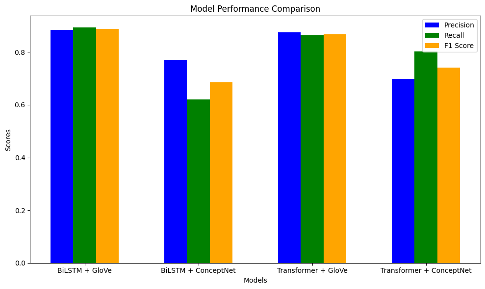

```python
# Defines the models and their corresponding performance metrics
models = ['BiLSTM + GloVe', 'BiLSTM + ConceptNet', 'Transformer + GloVe', 'Transformer + ConceptNet']
precision = [0.8851, 0.7694, 0.8755, 0.6985]
recall = [0.8929, 0.6199, 0.8636, 0.8029]
f1_score = [0.8883, 0.6851, 0.8679, 0.7419]

# Defines positions for the bars
x = np.arange(len(models))
width = 0.2  # The width of the bars

# Plots the bars
fig, ax = plt.subplots(figsize=(10, 6))

# Creates bars for precision, recall, and F1 score
ax.bar(x - width, precision, width, label='Precision', color='blue')
ax.bar(x, recall, width, label='Recall', color='green')
ax.bar(x + width, f1_score, width, label='F1 Score', color='orange')

# Adds labels and title
ax.set_xlabel('Models')
ax.set_ylabel('Scores')
ax.set_title('Model Performance Comparison')
ax.set_xticks(x)
ax.set_xticklabels(models)
ax.legend()

# Shows the plot
plt.tight_layout()
plt.show()
```

### **Analysis of Model Performance and Statistical Comparison**

In this lab, four deep learning models were evaluated for binary text classification. The models utilized two different neural architectures (BiLSTM and Transformer) combined with two distinct word embeddings (GloVe and ConceptNet). Each model's performance was assessed using precision, recall, and F1 score, which provide a comprehensive evaluation of their classification abilities. Below is an in-depth analysis of the results for each model.

#### **BiLSTM with GloVe Embeddings**

The BiLSTM model using GloVe embeddings achieved the following results:

- **Precision**: 0.8851
- **Recall**: 0.8929
- **F1 Score**: 0.8883

The **precision** of 0.8851 indicates that this model is highly effective at correctly identifying relevant instances while minimizing false positives. A high precision value suggests that the BiLSTM with GloVe embeddings consistently avoids over-classifying irrelevant instances, leading to a more accurate prediction.

The **recall** value of 0.8929 demonstrates the model's capability to identify the majority of true positive instances. This indicates that the model rarely misses relevant data, ensuring comprehensive coverage of positive instances in the classification task.

The **F1 Score**, which harmonizes precision and recall, is 0.8883. This score reflects the overall strength of the model in balancing false positives and false negatives. A high F1 score close to both precision and recall suggests that this model provides consistent and reliable performance across the metrics.

This performance highlights the effectiveness of combining the **BiLSTM architecture** with **GloVe embeddings**, which provide dense and semantically rich representations of words. The BiLSTM's ability to process sequences bidirectionally enables it to capture both past and future contexts, further enhancing classification performance.

#### **BiLSTM with ConceptNet Embeddings**

The BiLSTM model with ConceptNet embeddings produced the following results:

- **Precision**: 0.7694
- **Recall**: 0.6199
- **F1 Score**: 0.6851

The **precision** of 0.7694, while moderate, is significantly lower than that achieved with GloVe embeddings. This suggests that the model is less effective at avoiding false positives and tends to classify a higher proportion of irrelevant instances as relevant.

The **recall** of 0.6199 indicates a substantial drop in the model’s ability to identify true positive instances. A low recall value suggests that the model frequently misses relevant data, which could result in an incomplete understanding of the classification task.

The **F1 Score** of 0.6851 reflects a compromised balance between precision and recall, further highlighting the challenges faced by this model. While ConceptNet embeddings incorporate commonsense knowledge, their representations may not be as dense or contextually informative as GloVe embeddings, leading to weaker performance in tasks requiring nuanced semantic understanding.

Overall, the results suggest that ConceptNet embeddings are less effective for this specific task when paired with a BiLSTM architecture, likely due to their focus on abstract relationships rather than the dense semantic patterns captured by GloVe embeddings.

#### **Transformer with GloVe Embeddings**

The Transformer model with GloVe embeddings achieved the following results:

- **Precision**: 0.8755
- **Recall**: 0.8636
- **F1 Score**: 0.8679

The **precision** of 0.8755 is slightly lower than that of the BiLSTM with GloVe embeddings. This indicates that the Transformer performs well in minimizing false positives, though it is marginally less precise than the BiLSTM counterpart.

The **recall** of 0.8636 is similarly strong, demonstrating the model's ability to capture most relevant instances. The recall is slightly lower than that of the BiLSTM, suggesting that the Transformer may occasionally miss some relevant instances.

The **F1 Score** of 0.8679 reflects a solid balance between precision and recall, although it does not surpass the performance of the BiLSTM with GloVe embeddings. While Transformers are known for their ability to model long-range dependencies through self-attention mechanisms, the results indicate that this added complexity does not lead to a substantial improvement for this task.

These findings underscore the strength of **GloVe embeddings** in capturing semantic relationships. However, the performance similarity between the BiLSTM and Transformer models suggests that the task may not require the Transformer's advanced capabilities, allowing simpler architectures like BiLSTM to perform competitively.

#### **Transformer with ConceptNet Embeddings**

The Transformer model using ConceptNet embeddings produced the following results:

- **Precision**: 0.6985
- **Recall**: 0.8029
- **F1 Score**: 0.7419

The **precision** of 0.6985 is the lowest among all models, indicating a significant challenge in minimizing false positives. This suggests that the model frequently misclassifies irrelevant instances as relevant, reducing its overall accuracy.

The **recall** of 0.8029 is relatively high compared to its precision, suggesting that the model captures a substantial proportion of true positives. However, this comes at the cost of precision, as the model sacrifices specificity to capture more relevant instances.

The **F1 Score** of 0.7419 reflects the struggle of this model to balance precision and recall effectively. The ConceptNet embeddings, while valuable for capturing commonsense knowledge, appear to limit the Transformer's potential by failing to provide the dense, contextually rich information needed for this task.

These results suggest that the **Transformer with ConceptNet embeddings** underperforms compared to its counterparts, further emphasizing the importance of selecting appropriate embeddings based on the task requirements.

### **Conclusion**

In summary:

1. The **BiLSTM with GloVe embeddings** outperformed all other models, achieving the highest precision, recall, and F1 score. This demonstrates the effectiveness of combining BiLSTM’s sequential modeling capabilities with GloVe's dense semantic embeddings.
2. The **Transformer with GloVe embeddings** also performed strongly but did not significantly surpass the BiLSTM with GloVe. This suggests that the additional complexity of the Transformer architecture is not necessary for this particular task.
3. Both models utilizing **ConceptNet embeddings**—the BiLSTM and Transformer—performed poorly compared to their GloVe counterparts. The ConceptNet embeddings appear to lack the dense semantic richness required for this classification task.

These findings highlight the critical role of embedding selection in model performance. While advanced architectures like Transformers can offer substantial benefits for certain tasks, simpler architectures like BiLSTMs can excel when paired with well-suited embeddings like GloVe. Future work should focus on exploring additional embeddings, such as fine-tuned transformer-based models, to further optimize performance for similar tasks.